# Olympic Games. Data exploration

#### 0. Libraries

```python
import pandas as pd
import numpy as np
import seaborn as sns
import matplotlib.pylab as plt
```

## 1. Load Data

```python
athletes = pd.read_csv("athletes.csv").drop_duplicates()
athletes.head(1)
```

|  | id | name | gender | age | height | weight |
| --- | --- | --- | --- | --- | --- | --- |
| 0 | 51 | Nstor Abad Sanjun | M | 23 | 167.0 | 64.0 |

```python
country = pd.read_csv("countries.csv").drop_duplicates()
country.head(1)
```

|  | id | country | region |
| --- | --- | --- | --- |
| 0 | 1 | AFG - Afghanistan | ASIA (EX. NEAR EAST) |

```python
stats = pd.read_csv("country_stats.csv").drop_duplicates()
stats.head(1)
```

|  | year | country_id | gdp | population | nobel_prize_winners |
| --- | --- | --- | --- | --- | --- |
| 0 | 2000-01-01 | 1 | NaN | 20093756.0 | NaN |

```python
summer = pd.read_csv("summer_games.csv").drop_duplicates()
summer.head(1)
```

|  | sport | event | year | athlete_id | country_id | medal |
| --- | --- | --- | --- | --- | --- | --- |
| 0 | Gymnastics | Gymnastics Men's Individual All-Around | 2016-01-01 | 51 | 173 | NaN |

```python
winter = pd.read_csv("winter_games.csv").drop_duplicates()
winter.head(1)
```

|  | sport | event | year | athlete_id | country_id | medal |
| --- | --- | --- | --- | --- | --- | --- |
| 0 | Alpine Skiing | Alpine Skiing Women's Slalom | 2014-01-01 | 126 | 89 | NaN |

## 2. Pre-process Data

### 2.1 Basic transformations

```python
athletes = athletes.rename(columns={"id":"athlete_id"})
```

Drop the youngest entry for athlete 127594 because it is duplicated.

```python
athletes = athletes.loc[~((athletes["athlete_id"] == 127594) & (athletes["age"] == 28)), :]
```

Drop NA values and separate country code from country name.

```python
country = country.dropna()
country[['country_code','country_name']] = country["country"].str.split("-",expand=True,)
country = country.drop(["country"], axis=1)
country = country.rename(columns={"id":"country_id"})
```

Replace missing values and transform the year to YYYY format.

```python
stats = stats.replace(np.NaN, 0)
stats["year"] = stats["year"].astype(str).str[0:4].astype(int)
```

Transform the year to YYYY formats and replace NaNs in `medal` with "No Medal".

```python
summer["year"] = summer["year"].astype(str).str[0:4].astype(int)
summer["medal"] = summer["medal"].replace(np.NaN, "No medal")
```

Transform the year to YYYY formats and replace NaNs in `medal` with "No Medal".

```python
winter["year"] = winter["year"].astype(str).str[0:4].astype(int)
winter["medal"] = winter["medal"].replace(np.NaN, "No medal")
winter.head(1)
```

|  | sport | event | year | athlete_id | country_id | medal |
| --- | --- | --- | --- | --- | --- | --- |
| 0 | Alpine Skiing | Alpine Skiing Women's Slalom | 2014 | 126 | 89 | No medal |

### 2.2 Joins

First, join the `country` dataset with the `stats` dataset by `country_id`:

```python
country_stats = country.merge(stats, on="country_id", how="left")
country_stats.head(1)
```

|  | country_id | region | country_code | country_name | year | gdp | population | nobel_prize_winners |
| --- | --- | --- | --- | --- | --- | --- | --- | --- |
| 0 | 1 | ASIA (EX. NEAR EAST) | AFG | Afghanistan | 2000 | 0.0 | 20093756.0 | 0.0 |

Then, add the country information to the `athletes`.

The relation `country_id` to `athlete_id` is contained in the `summer` and `winter` datasets, so first we extract it and get the 4215 athletes with their countries.

```python
ath_co_summer = summer[["athlete_id", "country_id"]].drop_duplicates()
ath_co_winter = winter[["athlete_id", "country_id"]].drop_duplicates()
ath_co = pd.concat([ath_co_summer, ath_co_winter]).drop_duplicates()
```

Add the country ID to the `athletes`:

```python
athletes = athletes.merge(ath_co, how="left")
athletes.head(1)
```

|  | athlete_id | name | gender | age | height | weight | country_id |
| --- | --- | --- | --- | --- | --- | --- | --- |
| 0 | 51 | Nstor Abad Sanjun | M | 23 | 167.0 | 64.0 | 173 |

Join with the country data:

```python
athletes_country = athletes.merge(country_stats, how="left")
athletes_country.head(1)
```

|  | athlete_id | name | gender | age | height | weight | country_id | region | country_code | country_name | year | gdp | population | nobel_prize_winners |
| --- | --- | --- | --- | --- | --- | --- | --- | --- | --- | --- | --- | --- | --- | --- |
| 0 | 51 | Nstor Abad Sanjun | M | 23 | 167.0 | 64.0 | 173 | WESTERN EUROPE | ESP | Spain | 2000.0 | 5.954030e+11 | 40567864.0 | 0.0 |

Finally we can add the athletes´ information to the `summer` and `winter` datasets, making sure that we only keep the year of the games.

```python
summer_full = summer.merge(athletes_country, how="left")
summer_full.head(1)
```

|  | sport | event | year | athlete_id | country_id | medal | name | gender | age | height | weight | region | country_code | country_name | gdp | population | nobel_prize_winners |
| --- | --- | --- | --- | --- | --- | --- | --- | --- | --- | --- | --- | --- | --- | --- | --- | --- | --- |
| 0 | Gymnastics | Gymnastics Men's Individual All-Around | 2016 | 51 | 173 | No medal | Nstor Abad Sanjun | M | 23.0 | 167.0 | 64.0 | WESTERN EUROPE | ESP | Spain | 1.237260e+12 | 46484062.0 | 0.0 |

```python
winter_full = winter.merge(athletes_country, how="left")
winter_full.head(1)
```

|  | sport | event | year | athlete_id | country_id | medal | name | gender | age | height | weight | region | country_code | country_name | gdp | population | nobel_prize_winners |
| --- | --- | --- | --- | --- | --- | --- | --- | --- | --- | --- | --- | --- | --- | --- | --- | --- | --- |
| 0 | Alpine Skiing | Alpine Skiing Women's Slalom | 2014 | 126 | 89 | No medal | Forough Abbasi | F | 20 | 164.0 | 58.0 | ASIA (EX. NEAR EAST) | IRI | Iran | 4.344750e+11 | 78411092.0 | 0.0 |

## 3. Exercises

### 3.2

Number of athletes of 3 top sports in summer games:

```python
summer_full[["sport", "athlete_id"]].drop_duplicates().groupby("sport").size()
```

```
sport
Gymnastics          196
Swimming            942
Track and Field    2269
dtype: int64
```

Or by event:

```python
summer_full[["event", "athlete_id"]].drop_duplicates().groupby("event").size().head(3)
```

```
event
Gymnastics Men's Floor Exercise    72
Gymnastics Men's Horizontal Bar    71
Gymnastics Men's Horse Vault       17
dtype: int64
```

### 3.3

Create a report that shows every sport's number of unique events and unique athletes

**Summer**

```python
sport_event_summer = summer_full[["sport", "event"]].drop_duplicates().groupby(["sport"]).size()
sport_event_summer = sport_event_summer.reset_index()
sport_event_summer = sport_event_summer.rename(columns={0:"nr_unique_events"})
sport_event_summer
```

|  | sport | nr_unique_events |
| --- | --- | --- |
| 0 | Gymnastics | 14 |
| 1 | Swimming | 34 |
| 2 | Track and Field | 47 |

```python
sport_ath_summer = summer_full[["sport", "athlete_id"]].drop_duplicates().groupby(["sport"]).size()
sport_ath_summer = sport_ath_summer.reset_index()
sport_ath_summer = sport_ath_summer.rename(columns={0:"nr_athletes"})
sport_ath_summer
```

|  | sport | nr_athletes |
| --- | --- | --- |
| 0 | Gymnastics | 196 |
| 1 | Swimming | 942 |
| 2 | Track and Field | 2269 |

```python
sport_events_ath = sport_event_summer.merge(sport_ath_summer)
sport_events_ath
```

|  | sport | nr_unique_events | nr_athletes |
| --- | --- | --- | --- |
| 0 | Gymnastics | 14 | 196 |
| 1 | Swimming | 34 | 942 |
| 2 | Track and Field | 47 | 2269 |

**Winter**

```python
sport_event_winter = winter_full[["sport", "event"]].drop_duplicates().groupby(["sport"]).size()
sport_event_winter = sport_event_winter.reset_index()
sport_event_winter = sport_event_winter.rename(columns={0:"nr_unique_events"})
sport_event_winter
```

|  | sport | nr_unique_events |
| --- | --- | --- |
| 0 | Alpine Skiing | 10 |
| 1 | Biathlon | 11 |
| 2 | Cross Country Skiing | 12 |

```python
sport_ath_winter = winter_full[["sport", "athlete_id"]].drop_duplicates().groupby(["sport"]).size()
sport_ath_winter = sport_ath_winter.reset_index()
sport_ath_winter = sport_ath_winter.rename(columns={0:"nr_athletes"})
sport_ath_winter
```

|  | sport | nr_athletes |
| --- | --- | --- |
| 0 | Alpine Skiing | 314 |
| 1 | Biathlon | 204 |
| 2 | Cross Country Skiing | 298 |

```python
sport_events_ath = sport_event_winter.merge(sport_ath_winter)
sport_events_ath
```

|  | sport | nr_unique_events | nr_athletes |
| --- | --- | --- | --- |
| 0 | Alpine Skiing | 10 | 314 |
| 1 | Biathlon | 11 | 204 |
| 2 | Cross Country Skiing | 12 | 298 |

### 3.4

Age of oldest athlete by region.

```python
athletes_country[["region", "age"]].groupby("region").max("age").reset_index()
```

|  | region | age |
| --- | --- | --- |
| 0 | ASIA (EX. NEAR EAST) | 44 |
| 1 | BALTICS | 39 |
| 2 | C.W. OF IND. STATES | 41 |
| 3 | EASTERN EUROPE | 39 |
| 4 | LATIN AMER. & CARIB | 55 |
| 5 | NEAR EAST | 40 |
| 6 | NORTHERN AFRICA | 41 |
| 7 | NORTHERN AMERICA | 41 |
| 8 | OCEANIA | 40 |
| 9 | SUB-SAHARAN AFRICA | 38 |
| 10 | WESTERN EUROPE | 46 |

### 3.5

Create a report that shows the unique number of events held for each sport

```python
sport_event_summer = summer_full[["sport", "event"]].drop_duplicates().groupby(["sport"]).size()
sport_event_summer = sport_event_summer.reset_index()
sport_event_summer = sport_event_summer.rename(columns={0:"nr_unique_events"})
sport_event_summer["season"] = "summer"
sport_event_summer
```

|  | sport | nr_unique_events | season |
| --- | --- | --- | --- |
| 0 | Gymnastics | 14 | summer |
| 1 | Swimming | 34 | summer |
| 2 | Track and Field | 47 | summer |

```python
sport_event_winter = winter_full[["sport", "event"]].drop_duplicates().groupby(["sport"]).size()
sport_event_winter = sport_event_winter.reset_index()
sport_event_winter = sport_event_winter.rename(columns={0:"nr_unique_events"})
sport_event_winter["season"] = "winter"
sport_event_winter
```

|  | sport | nr_unique_events | season |
| --- | --- | --- | --- |
| 0 | Alpine Skiing | 10 | winter |
| 1 | Biathlon | 11 | winter |
| 2 | Cross Country Skiing | 12 | winter |

```python
sport_event = pd.concat([sport_event_summer, sport_event_winter])
sport_event = sport_event.sort_values(by="nr_unique_events", ascending=False)
sport_event
```

|  | sport | nr_unique_events | season |
| --- | --- | --- | --- |
| 2 | Track and Field | 47 | summer |
| 1 | Swimming | 34 | summer |
| 0 | Gymnastics | 14 | summer |
| 2 | Cross Country Skiing | 12 | winter |
| 1 | Biathlon | 11 | winter |
| 0 | Alpine Skiing | 10 | winter |

### 3.6

Total bronze medals from summer games.

```python
summer[["medal"]].value_counts()
```

```
medal
No medal    4488
Gold         159
Silver       149
Bronze       141
dtype: int64
```

Bronze medals by country:

```python
summer_full.loc[summer_full["medal"] == "Bronze", ["country_name", "medal"]].value_counts()
```

```
country_name          medal
 Canada               Bronze    21
 United States        Bronze    20
 China                Bronze    15
 Great Britain        Bronze    14
 Australia            Bronze    12
 Japan                Bronze     8
 Bahamas              Bronze     5
 Russia               Bronze     5
 Ethiopia             Bronze     5
 Denmark              Bronze     4
 France               Bronze     4
 New Zealand          Bronze     3
 Hungary              Bronze     3
 Brazil               Bronze     2
 Jamaica              Bronze     2
 Italy                Bronze     2
 Germany              Bronze     2
 Belarus              Bronze     1
 Croatia              Bronze     1
 Kenya                Bronze     1
 Czech Republic       Bronze     1
 Poland               Bronze     1
 Cuba                 Bronze     1
 Serbia               Bronze     1
 Spain                Bronze     1
 Sweden               Bronze     1
 Switzerland          Bronze     1
 Trinidad and Tobago  Bronze     1
 Turkey               Bronze     1
 Ukraine              Bronze     1
 Kazakhstan           Bronze     1
dtype: int64
```

### 7. Interesting insights

#### Summary

- The USA was a major contributor of athletes to the olympic games (over 5% of the participants), both in summer and in winter.
- The USA are clearly superior in summer. They won 72 medals every 100 athletes.
- Norway is clearly superior in winter. They won 73 medals every 100 athletes.
- I suspect that countries in high latitudes are better at winter games.

I will use the `summer_full` and `winter_full` datasets (summer and winter games information, enriched with the country stats and athlete information).

First I create a dataframe with the amount of medals by country for both winter and summer games.

```python
medal_country_s = summer_full[["country_name", "medal"]].groupby(["country_name", "medal"]).size()
medal_country_s = pd.DataFrame(medal_country_s).reset_index().rename(columns={0:"nr_medals"})
medal_country_s = medal_country_s.pivot(index="country_name", columns="medal", values="nr_medals")
medal_country_s = medal_country_s.reset_index().replace(np.NaN, 0)
```

```python
medal_country_w = winter_full[["country_name", "medal"]].groupby(["country_name", "medal"]).size()
medal_country_w = pd.DataFrame(medal_country_w).reset_index().rename(columns={0:"nr_medals"})
medal_country_w = medal_country_w.pivot(index="country_name", columns="medal", values="nr_medals")
medal_country_w = medal_country_w.reset_index().replace(np.NaN, 0)
```

Then calculate the number of athletes by country:

```python
nr_ath = summer_full[["country_name", "athlete_id"]].drop_duplicates().groupby("country_name").size()
nr_ath = pd.DataFrame(nr_ath.reset_index()).rename(columns={0:"nr_participants"})
medal_country_s = medal_country_s.merge(nr_ath, how="left")
```

```python
nr_ath = winter_full[["country_name", "athlete_id"]].drop_duplicates().groupby("country_name").size()
nr_ath = pd.DataFrame(nr_ath.reset_index()).rename(columns={0:"nr_participants"})
medal_country_w = medal_country_w.merge(nr_ath, how="left")
```

Finally calculate proportions of medals by number of participants:

```python
medal_country_s["total_nr_medals"] = medal_country_s[["Bronze", "Gold", "Silver"]].sum(axis=1)
medal_country_s["prop_medals_participants"] = medal_country_s["total_nr_medals"]/medal_country_s["nr_participants"]
```

```python
medal_country_w["total_nr_medals"] = medal_country_w[["Bronze", "Gold", "Silver"]].sum(axis=1)
medal_country_w["prop_medals_participants"] = medal_country_w["total_nr_medals"]/medal_country_w["nr_participants"]
```

#### 7.1 Number of participants by country

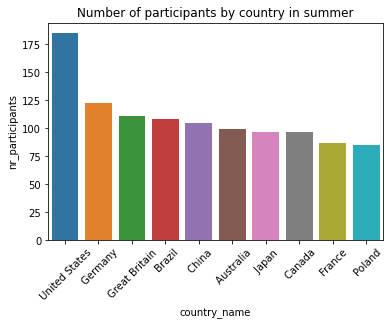

```python
part = sns.barplot(
    data=medal_country_s.sort_values(by="nr_participants", ascending=False).head(10),
    x="country_name",
    y="nr_participants"
)
part.set_title("Number of participants by country in summer")
plt.xticks(rotation=45)
plt.show()
```

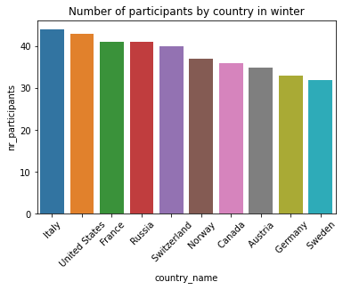

```python
part = sns.barplot(
    data=medal_country_w.sort_values(by="nr_participants", ascending=False).head(10),
    x="country_name",
    y="nr_participants"
)
part.set_title("Number of participants by country in winter")
plt.xticks(rotation=45)
plt.show()
```

**INSIGHTS:**

- The USA was a major contributor of athletes to the olympic games (over 5%), both in summer and in winter.

#### 7.1 Proportion of medals by country

The **top 10 countries** with more **medals by participant** are:

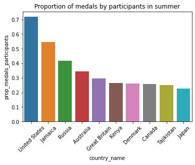

```python
part = sns.barplot(
    data=medal_country_s.sort_values(by="prop_medals_participants", ascending=False).head(10),
    x="country_name",
    y="prop_medals_participants"
)
part.set_title("Proportion of medals by participants in summer")
plt.xticks(rotation=45)
plt.show()
```

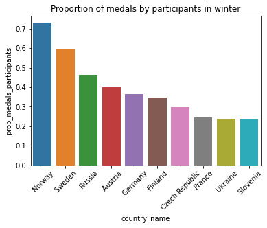

```python
part = sns.barplot(
    data=medal_country_w.sort_values(by="prop_medals_participants", ascending=False).head(10),
    x="country_name",
    y="prop_medals_participants"
)
part.set_title("Proportion of medals by participants in winter")
plt.xticks(rotation=45)
plt.show()
```

**INSIGHTS:**

- The USA are clearly superior in summer. They won 72 medals every 100 athletes.
- Norway is clearly superior in winter. They won 73 medals every 100 athletes.

#### 7.3 Relationship between country latitude and winter games

The data shows that the top 10 countries in the 2014 winter games are located mainly in Northern or Western Europe. Therefore I suspect that countries in high latitudes are better at winter games.

```python
medal_country_w[["country_name", "Gold", "Silver", "Bronze", "No medal", "nr_participants", "prop_medals_participants"]].sort_values(by="prop_medals_participants", ascending=False).head(10)
```

|  | country_name | Gold | Silver | Bronze | No medal | nr_participants | prop_medals_participants |
| --- | --- | --- | --- | --- | --- | --- | --- |
| 52 | Norway | 13.0 | 3.0 | 11.0 | 86.0 | 37 | 0.729730 |
| 65 | Sweden | 8.0 | 5.0 | 6.0 | 61.0 | 32 | 0.593750 |
| 58 | Russia | 5.0 | 12.0 | 2.0 | 88.0 | 41 | 0.463415 |
| 5 | Austria | 3.0 | 5.0 | 6.0 | 75.0 | 35 | 0.400000 |
| 25 | Germany | 1.0 | 6.0 | 5.0 | 87.0 | 33 | 0.363636 |
| 22 | Finland | 2.0 | 6.0 | 0.0 | 50.0 | 23 | 0.347826 |
| 18 | Czech Republic | 0.0 | 6.0 | 2.0 | 84.0 | 27 | 0.296296 |
| 23 | France | 2.0 | 2.0 | 6.0 | 96.0 | 41 | 0.243902 |
| 72 | Ukraine | 4.0 | 0.0 | 1.0 | 62.0 | 21 | 0.238095 |
| 62 | Slovenia | 2.0 | 0.0 | 2.0 | 55.0 | 17 | 0.235294 |